# 2004’ten günümüze Türkiye’de İthal Lüks Otomobil Satışları’

## Verilerin derlenmesi

`http://www.odd.org.tr/web_2837_1/index.aspx` sitesinde aylık ve yıllık olarak pdf formatında ayrı raporlarda tutulan satış verileri önce Microsoft Excel kullanılarak birleştirilmiş, veri yapısında bulunan eksiklikler ve düzensizlikler giderilerek toplamda 13 yıllık satış verisi oluşturulmuştur. Bu veri seti sonrasında `otoData<-readxl::read_excel("OtomobilSatisRefined.xlsx")` komutu kullanılarak R ortamına aktarılmıştır.

```r
otoData<-readxl::read_excel("OtomobilSatisRefined.xlsx")
```

Daha sonra Türkiye piyasasında faaliyet gösteren lüks otomobil firmaları aşağıdaki şekilde filtrelenerek üzerinde asıl çalışılacak olan veri seti oluşturulmuştur.

```r
luxotodata = otoData %>% filter(MARKA == "AUDI" | MARKA == "BMW"|MARKA == "FERRARI" | MARKA == "JAGUAR" | MARKA == "LAMBORGHINI"|MARKA == "LANDROVER" | MARKA == "MASERATI"|MARKA == "PORSCHE" | MARKA == "BENTLEY"|MARKA == "MERCEDES-BENZ" )
```

Seçilen markaların yıllara göre değişen genel toplam satış sayılarına ilişkin grafik aşağıdaki gibidir. Grafikten görüleceği üzere 2004 - 2016 yılları arasında lüks otomobil piyasasında toplam satışlar 2008 yılı hariç her yıl bir önceki yıla göre artış göstermektedir. 2008 yılında ise 2007 yılına göre lüks araç piyasasında bir daralmadan söz edilebilir. Bu duruma sebep olarak 2008 yılında ABD emlak piyasasında başlayan ve pek çok global finans kurumunu etkileyen mortgage krizinin Türkiye ekonomisine olan etkisi olduğu düşünülebilir.

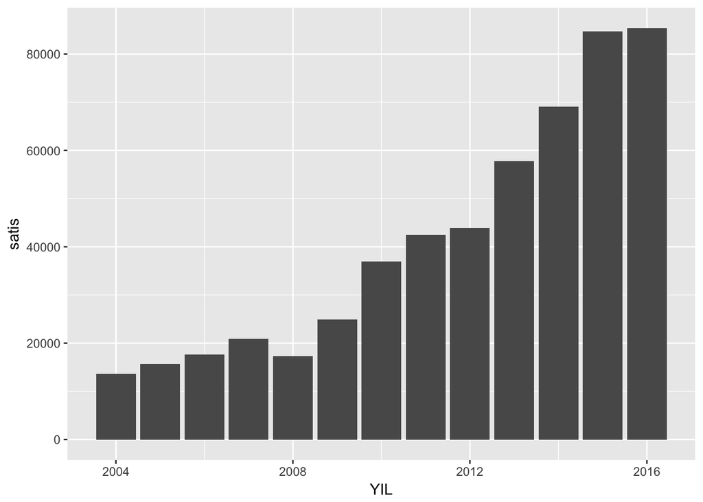

```r
bar_grafik = luxotodata %>%
group_by (YIL) %>%
summarise (satis = sum(o_TOPLAM)) %>%
ungroup()

#ggplot(data = bar_grafik, aes(x=YIL, y = satis)) + geom_bar(stat = "identity", fill = "#00FF84")
ggplot(data = bar_grafik, aes(x=YIL, y = satis)) + geom_bar(stat = "identity")
```

### Genel Satışların Seçilen Markalara Göre Dağılımı

Türkiye otomobil pazarında faaliyet gösteren otomotiv firmalarından AUDI, BMW, FERRARI, JAGUAR, LANDROVER, LAMBORGHINI, LANDROVER, MASERATI, PORSCHE, BENTLEY, ve MERCEDES-BENZ diğer otomotiv firmalarına kıyasla fiyat ve kalite olarak daha üst markalar olarak değerlendirildiğinden bu otomotiv firmalarının yıllara göre satış dağılımı ayrıca incelenmiştir.

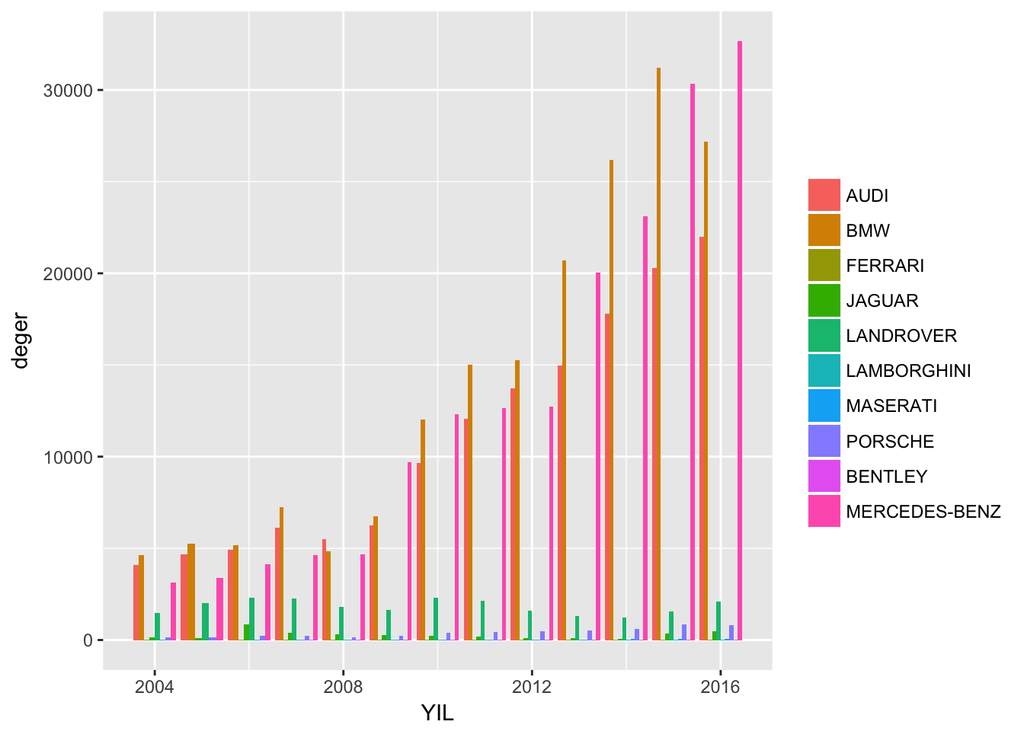

```r
luxoto_veri2 <-
luxotodata %>%
#İlgili sütunları seç
select(MARKA,YIL,o_TOPLAM) %>%
group_by(YIL,MARKA) %>%
#sandıktaki değerleri ilçe ve parametreye göre topla
summarise(deger=sum(o_TOPLAM)) %>%
ungroup()

multidatagrafik<-
ggplot(data=luxoto_veri2,aes(x=YIL,y=deger,fill=ordered(MARKA,levels=c("AUDI" , "BMW" , "FERRARI" , "JAGUAR" , "LANDROVER" , "LAMBORGHINI" , "LANDROVER" , "MASERATI" , "PORSCHE" , "BENTLEY" , "MERCEDES-BENZ")))) + geom_bar(stat="identity",position="dodge") + labs(fill="")
multidatagrafik
```

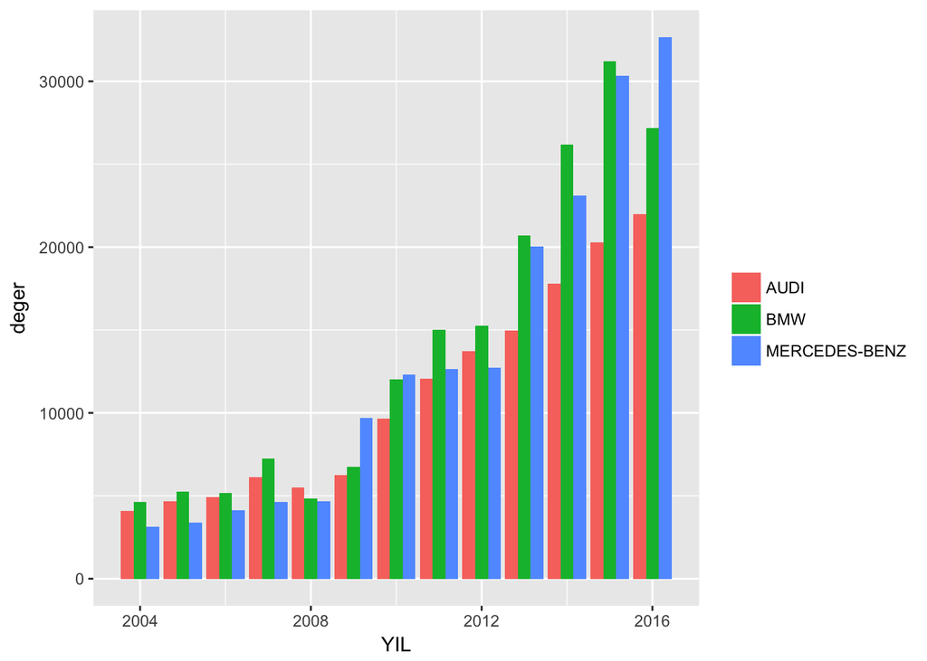

```r
multidatagrafik<-
ggplot(data=luxoto_veri2 %>% filter((MARKA %in% c("AUDI","BMW","MERCEDES-BENZ"))) ,aes(x=YIL,y=deger,fill=ordered(MARKA,levels=c("AUDI" , "BMW" , "FERRARI" , "JAGUAR" , "LANDROVER" , "LAMBORGHINI" , "LANDROVER" , "MASERATI" , "PORSCHE" , "BENTLEY" , "MERCEDES-BENZ")))) + geom_bar(stat="identity",position="dodge") + labs(fill="")
multidatagrafik
```

Lüks araç segmentini domine eden üç otomobil firması veri setinden çıkartılarak kalan otomobil firmaları için yapılan analiz sonuçları (FERRARI, JAGUAR, LANDROVER, LAMBORGHINI, LANDROVER, MASERATI, PORSCHE, ve BENTLEY) aşağıdaki grafikte verilmiştir.

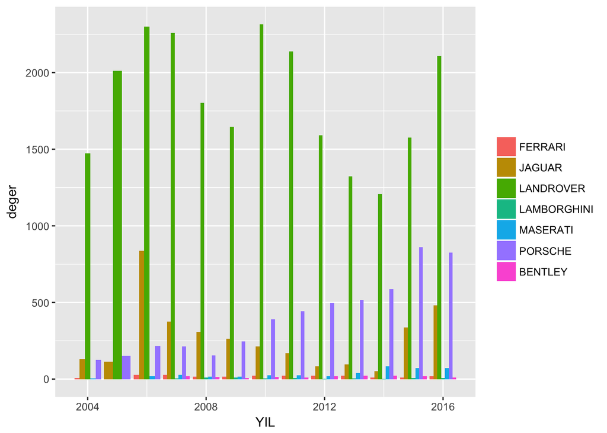

```r
multidatagrafik<-
ggplot(data=luxoto_veri2 %>% filter(!(MARKA %in% c("AUDI","BMW","MERCEDES-BENZ"))) ,aes(x=YIL,y=deger,fill=ordered(MARKA,levels=c("AUDI" , "BMW" , "FERRARI" , "JAGUAR" , "LANDROVER" , "LAMBORGHINI" , "LANDROVER" , "MASERATI" , "PORSCHE" , "BENTLEY" , "MERCEDES-BENZ")))) + geom_bar(stat="identity",position="dodge") + labs(fill="")
multidatagrafik
```

Üç büyükler olarak nitelendirilen AUDI, BMW ve MERCEDES-BENZ veri setinden çıkartılarak analiz tekrarlandığında kalan markalar olan FERRARI, JAGUAR, LANDROVER, LAMBORGHINI, LANDROVER, MASERATI, PORSCHE, ve BENTLEY arasında pazarın ağırlıklı olarak LAND-ROVER tarafından domine edildiği ortaya çıkmaktadır. 2004-2016 yılları arasında tüm yıllarda LAND-ROVER satış sayısı olarak önde gitmekte, diğer markaların satış fiyatlarında düzenli bir artış ya da azalış eğilimi gözlenmemektedir. Yalnızca JAGUAR marka araçların satış rakamlarında 2006 yılında gözlemlenen artışın izleyen yıllarda devam ettirilemediği de görülmektedir. PORSCHE markasının ise özellikle 2008 yılından başlayarak artan araç satışları sayısıyla da paralel bir artış eğilimen girdiğini söylemek mümkündür.

### Rmd dosyasından html dosyasına nasıl dönüştürülür?

Eğer rmarkdown ve pandoc yüklüyse `render` komutu kullanılır. Aşağıdaki komut bilgisayardan bir dosya seçip html çıktısı almanızı sağlar.

```r
rmarkdown::render(file=file.choose(),output_format="html")
```

### Analizi hazırlayanlar: